# Logistic regression

Jeffrey Chrabaszcz  
9 January 2014

### Modeling competition

1. Some number of teams.
2. Use any combination or transformation of the data in **ravensdata.csv** to predict “ravens”.
3. Best AIC for an interpretable and graphable model wins.

### Outline

1. Logistic regression functions
2. Fitting a logistic regression
3. Graphing logistic regressions
4. Interpretting logistic regression coefficients

### Logistic regression

To handle dichotomous outcome variables, we need the logistic, (and logit), functions.

\[ P(y_i = 1) = logit^{-1}(X_i\beta) \]

\[ logit(p) = log\left(\frac{p}{(1 - p)}\right) \]

### Logistic function

\[ logit^{-1}(x) = \frac{1}{(1 + e^{-x})}, logit^{-1}(x) = \frac{e^x}{(1 + e^{x})} \]

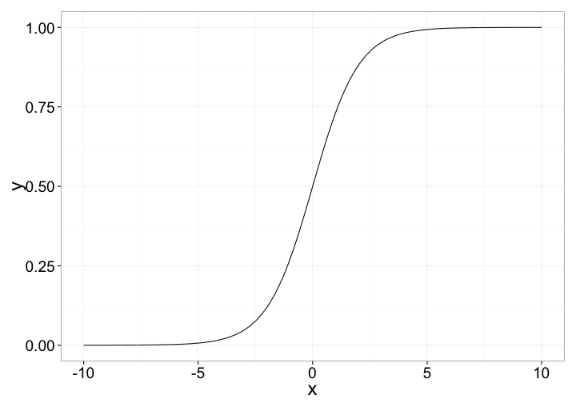

### Alternate formulation

You can think of this as a two-step process. First:

\[ logit(p_i) = X_i\beta \]

This rescales our predictions to range form 0 to 1. Then:

\[ P(y_i = 1) = p_i \]

Even if this doesn't help you understand logistic regression, put a pin in it.

### Fitting a logistic regression

```
glm(formula = menarche ~ age, family = binomial, data = juul.girl)
            coef.est coef.se
(Intercept) -20.01     2.03
age           1.52     0.15
---
  n = 519, k = 2
  residual deviance = 200.7, null deviance = 719.4 (difference = 518.7)
```

How can we determine the median matricarcheal age? Set \( logit(p) \) equal to 0, which returns the value of age corresponding to a 50% prediction.

```r
20.01/1.52
```

```
[1] 13.2
```

### Quick graph for one predictor

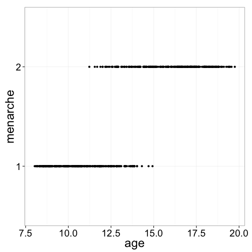

```r
qplot(age, menarche, data = juul.girl) + theme_bw(base_size = 24)
```

### Better graph

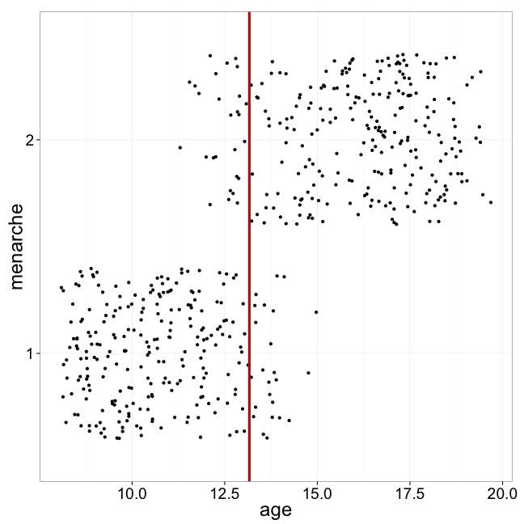

### Interpreting logistic regression coefficients

Logistic regression coefficients change across the range of the function. A few things can help interpretation:

1. Gelman's “divide by 4” rule.
2. Exponentiate the coefficient

```r
invlogit(1.52)
```

```
[1] 0.821
```

```r
exp(1.52)
```

```
[1] 4.57
```